# Risk Factor Analysis

## Outcome Variable

**Outcome Variable:** sstunted

## Predictor Variables

**Intervention Variable:** gagebrth

**Adjustment Set:**

- arm
- sex
- W_mage
- meducyrs
- feducyrs
- hhwealth_quart
- W_nrooms
- brthmon
- W_parity
- impsan
- delta_W_mage
- delta_meducyrs
- delta_feducyrs
- delta_hhwealth_quart
- delta_W_nrooms
- delta_brthmon
- delta_W_parity
- delta_impsan

## Stratifying Variables

The analysis was stratified on these variable(s):

- agecat
- studyid
- country

## Data Summary

| agecat | studyid | country | gagebrth | sstunted | n_cell | n |
| --- | --- | --- | --- | --- | --- | --- |
| Birth | CMC-V-BCS-2002 | INDIA | Full or late term | 0 | 55 | 92 |
| Birth | CMC-V-BCS-2002 | INDIA | Full or late term | 1 | 3 | 92 |
| Birth | CMC-V-BCS-2002 | INDIA | Preterm | 0 | 10 | 92 |
| Birth | CMC-V-BCS-2002 | INDIA | Preterm | 1 | 1 | 92 |
| Birth | CMC-V-BCS-2002 | INDIA | Early term | 0 | 23 | 92 |
| Birth | CMC-V-BCS-2002 | INDIA | Early term | 1 | 0 | 92 |
| Birth | COHORTS | GUATEMALA | Full or late term | 0 | 338 | 617 |
| Birth | COHORTS | GUATEMALA | Full or late term | 1 | 3 | 617 |
| Birth | COHORTS | GUATEMALA | Preterm | 0 | 91 | 617 |
| Birth | COHORTS | GUATEMALA | Preterm | 1 | 4 | 617 |
| Birth | COHORTS | GUATEMALA | Early term | 0 | 179 | 617 |
| Birth | COHORTS | GUATEMALA | Early term | 1 | 2 | 617 |
| Birth | COHORTS | INDIA | Full or late term | 0 | 562 | 1293 |
| Birth | COHORTS | INDIA | Full or late term | 1 | 8 | 1293 |
| Birth | COHORTS | INDIA | Preterm | 0 | 269 | 1293 |
| Birth | COHORTS | INDIA | Preterm | 1 | 16 | 1293 |
| Birth | COHORTS | INDIA | Early term | 0 | 431 | 1293 |
| Birth | COHORTS | INDIA | Early term | 1 | 7 | 1293 |
| Birth | COHORTS | PHILIPPINES | Full or late term | 0 | 1161 | 3024 |
| Birth | COHORTS | PHILIPPINES | Full or late term | 1 | 3 | 3024 |
| Birth | COHORTS | PHILIPPINES | Preterm | 0 | 618 | 3024 |
| Birth | COHORTS | PHILIPPINES | Preterm | 1 | 31 | 3024 |
| Birth | COHORTS | PHILIPPINES | Early term | 0 | 1199 | 3024 |
| Birth | COHORTS | PHILIPPINES | Early term | 1 | 12 | 3024 |
| Birth | IRC | INDIA | Full or late term | 0 | 228 | 369 |
| Birth | IRC | INDIA | Full or late term | 1 | 10 | 369 |
| Birth | IRC | INDIA | Preterm | 0 | 33 | 369 |
| Birth | IRC | INDIA | Preterm | 1 | 3 | 369 |
| Birth | IRC | INDIA | Early term | 0 | 93 | 369 |
| Birth | IRC | INDIA | Early term | 1 | 2 | 369 |

[output cut: 144 more lines]

The following strata were considered:

- agecat: 24 months, studyid: CMC-V-BCS-2002, country: INDIA
- agecat: 24 months, studyid: COHORTS, country: GUATEMALA
- agecat: 24 months, studyid: COHORTS, country: INDIA
- agecat: 24 months, studyid: COHORTS, country: PHILIPPINES
- agecat: 24 months, studyid: IRC, country: INDIA
- agecat: 24 months, studyid: JiVitA-3, country: BANGLADESH
- agecat: 24 months, studyid: Keneba, country: GAMBIA
- agecat: 24 months, studyid: NIH-Crypto, country: BANGLADESH
- agecat: 24 months, studyid: PROBIT, country: BELARUS
- agecat: 24 months, studyid: TanzaniaChild2, country: TANZANIA, UNITED REPUBLIC OF
- agecat: 6 months, studyid: CMC-V-BCS-2002, country: INDIA
- agecat: 6 months, studyid: COHORTS, country: GUATEMALA
- agecat: 6 months, studyid: COHORTS, country: INDIA
- agecat: 6 months, studyid: COHORTS, country: PHILIPPINES
- agecat: 6 months, studyid: IRC, country: INDIA
- agecat: 6 months, studyid: JiVitA-3, country: BANGLADESH
- agecat: 6 months, studyid: Keneba, country: GAMBIA
- agecat: 6 months, studyid: NIH-Crypto, country: BANGLADESH
- agecat: 6 months, studyid: PROBIT, country: BELARUS
- agecat: 6 months, studyid: TanzaniaChild2, country: TANZANIA, UNITED REPUBLIC OF
- agecat: Birth, studyid: CMC-V-BCS-2002, country: INDIA
- agecat: Birth, studyid: COHORTS, country: GUATEMALA
- agecat: Birth, studyid: COHORTS, country: INDIA
- agecat: Birth, studyid: COHORTS, country: PHILIPPINES
- agecat: Birth, studyid: IRC, country: INDIA
- agecat: Birth, studyid: JiVitA-3, country: BANGLADESH
- agecat: Birth, studyid: Keneba, country: GAMBIA
- agecat: Birth, studyid: NIH-Crypto, country: BANGLADESH
- agecat: Birth, studyid: PROBIT, country: BELARUS

### Dropped Strata

Some strata were dropped due to rare outcomes:

- agecat: Birth, studyid: CMC-V-BCS-2002, country: INDIA
- agecat: Birth, studyid: COHORTS, country: GUATEMALA
- agecat: Birth, studyid: COHORTS, country: PHILIPPINES
- agecat: Birth, studyid: IRC, country: INDIA
- agecat: Birth, studyid: NIH-Crypto, country: BANGLADESH
- agecat: Birth, studyid: PROBIT, country: BELARUS
- agecat: 6 months, studyid: IRC, country: INDIA
- agecat: 6 months, studyid: Keneba, country: GAMBIA
- agecat: 6 months, studyid: NIH-Crypto, country: BANGLADESH
- agecat: 6 months, studyid: TanzaniaChild2, country: TANZANIA, UNITED REPUBLIC OF
- agecat: 24 months, studyid: NIH-Crypto, country: BANGLADESH
- agecat: 24 months, studyid: PROBIT, country: BELARUS
- agecat: 24 months, studyid: TanzaniaChild2, country: TANZANIA, UNITED REPUBLIC OF

## Methods Detail

We’re interested in the causal parameters $E[Y_a]$ for all values of $a \in \mathcal{A}$. These parameters represent the mean outcome if, possibly contrary to fact, we intervened to set all units to have $A=a$. Under the randomization and positivity assumptions, these are identified by the statistical parameters $\psi_a=E_W[E_{Y|A,W}(Y|A=a,W)]$. In addition, we’re interested in the mean of $Y$, $E[Y]$ under no intervention (the observed mean). We will estimate these parameters by using SuperLearner to fit the relevant likelihood factors – $E_{Y|A,W}(Y|A=a,W)$ and $p(A=a|W)$, and then updating our likelihood fit using a joint TMLE.

For unadjusted analyses ($W=\{\}$), initial likelihoods were estimated using Lrnr_glm to estimate the simple $E(Y|A)$ and Lrnr_mean to estimate $p(A)$. For adjusted analyses, a small library containing Lrnr_glmnet, Lrnr_xgboost, and Lrnr_mean was used.

Having estimated these parameters, we will then use the delta method to estimate relative risks and attributable risks relative to a prespecified baseline level of $A$.

# Results Detail

## Results Plots

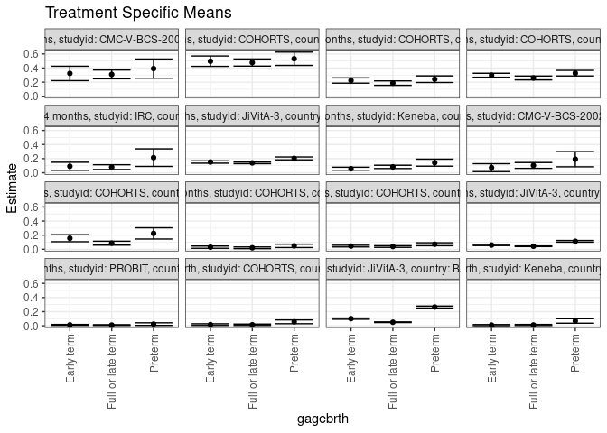

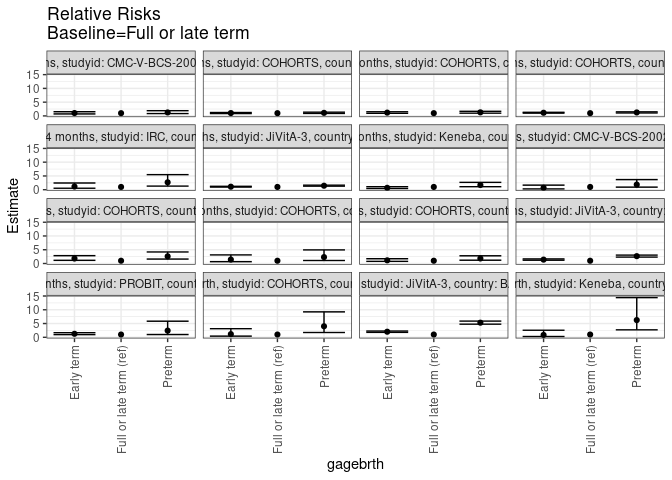

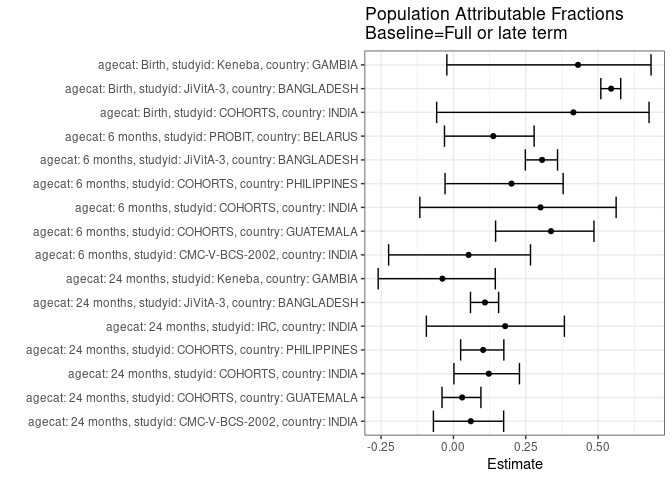

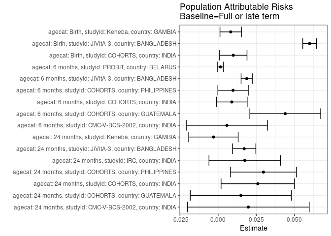

## Results Table

### Parameter: TSM

| agecat | studyid | country | intervention_level | baseline_level | estimate | ci_lower | ci_upper |
| --- | --- | --- | --- | --- | --- | --- | --- |
| Birth | COHORTS | INDIA | Full or late term | NA | 0.0140351 | 0.0043742 | 0.0236960 |
| Birth | COHORTS | INDIA | Preterm | NA | 0.0561404 | 0.0294051 | 0.0828756 |
| Birth | COHORTS | INDIA | Early term | NA | 0.0159817 | 0.0042330 | 0.0277305 |
| Birth | JiVitA-3 | BANGLADESH | Full or late term | NA | 0.0500047 | 0.0456180 | 0.0543913 |
| Birth | JiVitA-3 | BANGLADESH | Preterm | NA | 0.2650782 | 0.2511262 | 0.2790303 |
| Birth | JiVitA-3 | BANGLADESH | Early term | NA | 0.1009950 | 0.0925423 | 0.1094477 |
| Birth | Keneba | GAMBIA | Full or late term | NA | 0.0108992 | 0.0033854 | 0.0184130 |
| Birth | Keneba | GAMBIA | Preterm | NA | 0.0680851 | 0.0358691 | 0.1003011 |
| Birth | Keneba | GAMBIA | Early term | NA | 0.0091575 | 0.0011649 | 0.0171501 |
| 6 months | CMC-V-BCS-2002 | INDIA | Full or late term | NA | 0.1037736 | 0.0626625 | 0.1448847 |
| 6 months | CMC-V-BCS-2002 | INDIA | Preterm | NA | 0.1923077 | 0.0850337 | 0.2995817 |
| 6 months | CMC-V-BCS-2002 | INDIA | Early term | NA | 0.0722892 | 0.0164963 | 0.1280820 |
| 6 months | COHORTS | GUATEMALA | Full or late term | NA | 0.0864602 | 0.0586452 | 0.1142751 |
| 6 months | COHORTS | GUATEMALA | Preterm | NA | 0.2246018 | 0.1451092 | 0.3040944 |
| 6 months | COHORTS | GUATEMALA | Early term | NA | 0.1564004 | 0.1066212 | 0.2061797 |
| 6 months | COHORTS | INDIA | Full or late term | NA | 0.0207757 | 0.0090538 | 0.0324975 |
| 6 months | COHORTS | INDIA | Preterm | NA | 0.0481407 | 0.0238956 | 0.0723859 |
| 6 months | COHORTS | INDIA | Early term | NA | 0.0298546 | 0.0138977 | 0.0458115 |
| 6 months | COHORTS | PHILIPPINES | Full or late term | NA | 0.0389638 | 0.0271194 | 0.0508081 |
| 6 months | COHORTS | PHILIPPINES | Preterm | NA | 0.0712978 | 0.0502458 | 0.0923498 |
| 6 months | COHORTS | PHILIPPINES | Early term | NA | 0.0448520 | 0.0325790 | 0.0571250 |
| 6 months | JiVitA-3 | BANGLADESH | Full or late term | NA | 0.0423702 | 0.0381221 | 0.0466183 |
| 6 months | JiVitA-3 | BANGLADESH | Preterm | NA | 0.1129110 | 0.1013239 | 0.1244981 |
| 6 months | JiVitA-3 | BANGLADESH | Early term | NA | 0.0596823 | 0.0521578 | 0.0672069 |
| 6 months | PROBIT | BELARUS | Full or late term | NA | 0.0096838 | 0.0043240 | 0.0150436 |
| 6 months | PROBIT | BELARUS | Preterm | NA | 0.0233828 | 0.0048319 | 0.0419338 |
| 6 months | PROBIT | BELARUS | Early term | NA | 0.0122783 | 0.0057114 | 0.0188451 |
| 24 months | CMC-V-BCS-2002 | INDIA | Full or late term | NA | 0.3097538 | 0.2475029 | 0.3720047 |
| 24 months | CMC-V-BCS-2002 | INDIA | Preterm | NA | 0.3922463 | 0.2563482 | 0.5281444 |
| 24 months | CMC-V-BCS-2002 | INDIA | Early term | NA | 0.3235838 | 0.2211475 | 0.4260202 |
| 24 months | COHORTS | GUATEMALA | Full or late term | NA | 0.4783387 | 0.4279187 | 0.5287587 |
| 24 months | COHORTS | GUATEMALA | Preterm | NA | 0.5319797 | 0.4373926 | 0.6265667 |
| 24 months | COHORTS | GUATEMALA | Early term | NA | 0.4974997 | 0.4243063 | 0.5706932 |
| 24 months | COHORTS | INDIA | Full or late term | NA | 0.1865633 | 0.1551621 | 0.2179645 |
| 24 months | COHORTS | INDIA | Preterm | NA | 0.2419723 | 0.1948811 | 0.2890634 |
| 24 months | COHORTS | INDIA | Early term | NA | 0.2232530 | 0.1856078 | 0.2608981 |
| 24 months | COHORTS | PHILIPPINES | Full or late term | NA | 0.2595010 | 0.2321221 | 0.2868799 |
| 24 months | COHORTS | PHILIPPINES | Preterm | NA | 0.3273379 | 0.2876905 | 0.3669854 |
| 24 months | COHORTS | PHILIPPINES | Early term | NA | 0.2977611 | 0.2696751 | 0.3258471 |
| 24 months | IRC | INDIA | Full or late term | NA | 0.0800000 | 0.0463276 | 0.1136724 |
| 24 months | IRC | INDIA | Preterm | NA | 0.2142857 | 0.0900319 | 0.3385396 |
| 24 months | IRC | INDIA | Early term | NA | 0.0918367 | 0.0345858 | 0.1490877 |
| 24 months | JiVitA-3 | BANGLADESH | Full or late term | NA | 0.1399389 | 0.1283823 | 0.1514955 |
| 24 months | JiVitA-3 | BANGLADESH | Preterm | NA | 0.2032006 | 0.1829193 | 0.2234820 |
| 24 months | JiVitA-3 | BANGLADESH | Early term | NA | 0.1523741 | 0.1355880 | 0.1691602 |
| 24 months | Keneba | GAMBIA | Full or late term | NA | 0.0835184 | 0.0603531 | 0.1066836 |
| 24 months | Keneba | GAMBIA | Preterm | NA | 0.1428848 | 0.0930731 | 0.1926965 |
| 24 months | Keneba | GAMBIA | Early term | NA | 0.0573051 | 0.0359866 | 0.0786236 |

### Parameter: E(Y)

| agecat | studyid | country | intervention_level | baseline_level | estimate | ci_lower | ci_upper |
| --- | --- | --- | --- | --- | --- | --- | --- |
| Birth | COHORTS | INDIA | NA | NA | 0.0239753 | 0.0156340 | 0.0323165 |
| Birth | JiVitA-3 | BANGLADESH | NA | NA | 0.1099244 | 0.1052719 | 0.1145770 |
| Birth | Keneba | GAMBIA | NA | NA | 0.0191419 | 0.0122398 | 0.0260440 |
| 6 months | CMC-V-BCS-2002 | INDIA | NA | NA | 0.1095101 | 0.0766059 | 0.1424143 |
| 6 months | COHORTS | GUATEMALA | NA | NA | 0.1304348 | 0.1056973 | 0.1551723 |
| 6 months | COHORTS | INDIA | NA | NA | 0.0297256 | 0.0205326 | 0.0389187 |
| 6 months | COHORTS | PHILIPPINES | NA | NA | 0.0487533 | 0.0406091 | 0.0568974 |
| 6 months | JiVitA-3 | BANGLADESH | NA | NA | 0.0610868 | 0.0571240 | 0.0650496 |
| 6 months | PROBIT | BELARUS | NA | NA | 0.0112310 | 0.0054733 | 0.0169886 |
| 24 months | CMC-V-BCS-2002 | INDIA | NA | NA | 0.3295129 | 0.2801285 | 0.3788973 |
| 24 months | COHORTS | GUATEMALA | NA | NA | 0.4931921 | 0.4550499 | 0.5313343 |
| 24 months | COHORTS | INDIA | NA | NA | 0.2125382 | 0.1903591 | 0.2347173 |
| 24 months | COHORTS | PHILIPPINES | NA | NA | 0.2891914 | 0.2711388 | 0.3072440 |
| 24 months | IRC | INDIA | NA | NA | 0.0974359 | 0.0679665 | 0.1269053 |
| 24 months | JiVitA-3 | BANGLADESH | NA | NA | 0.1570349 | 0.1479400 | 0.1661298 |
| 24 months | Keneba | GAMBIA | NA | NA | 0.0804498 | 0.0647640 | 0.0961357 |

### Parameter: RR

| agecat | studyid | country | intervention_level | baseline_level | estimate | ci_lower | ci_upper |
| --- | --- | --- | --- | --- | --- | --- | --- |
| Birth | COHORTS | INDIA | Full or late term | Full or late term | 1.0000000 | 1.0000000 | 1.000000 |
| Birth | COHORTS | INDIA | Preterm | Full or late term | 4.0000000 | 1.7320013 | 9.237869 |
| Birth | COHORTS | INDIA | Early term | Full or late term | 1.1386986 | 0.4159430 | 3.117338 |
| Birth | JiVitA-3 | BANGLADESH | Full or late term | Full or late term | 1.0000000 | 1.0000000 | 1.000000 |
| Birth | JiVitA-3 | BANGLADESH | Preterm | Full or late term | 5.3010719 | 4.7717424 | 5.889120 |
| Birth | JiVitA-3 | BANGLADESH | Early term | Full or late term | 2.0197117 | 1.7984120 | 2.268243 |
| Birth | Keneba | GAMBIA | Full or late term | Full or late term | 1.0000000 | 1.0000000 | 1.000000 |
| Birth | Keneba | GAMBIA | Preterm | Full or late term | 6.2468085 | 2.7072028 | 14.414368 |
| Birth | Keneba | GAMBIA | Early term | Full or late term | 0.8402015 | 0.2762834 | 2.555125 |
| 6 months | CMC-V-BCS-2002 | INDIA | Full or late term | Full or late term | 1.0000000 | 1.0000000 | 1.000000 |
| 6 months | CMC-V-BCS-2002 | INDIA | Preterm | Full or late term | 1.8531469 | 0.9349126 | 3.673234 |
| 6 months | CMC-V-BCS-2002 | INDIA | Early term | Full or late term | 0.6966046 | 0.2925632 | 1.658643 |
| 6 months | COHORTS | GUATEMALA | Full or late term | Full or late term | 1.0000000 | 1.0000000 | 1.000000 |
| 6 months | COHORTS | GUATEMALA | Preterm | Full or late term | 2.5977489 | 1.6122020 | 4.185765 |
| 6 months | COHORTS | GUATEMALA | Early term | Full or late term | 1.8089309 | 1.1514985 | 2.841715 |
| 6 months | COHORTS | INDIA | Full or late term | Full or late term | 1.0000000 | 1.0000000 | 1.000000 |
| 6 months | COHORTS | INDIA | Preterm | Full or late term | 2.3171680 | 1.0886956 | 4.931835 |
| 6 months | COHORTS | INDIA | Early term | Full or late term | 1.4369997 | 0.6612289 | 3.122925 |
| 6 months | COHORTS | PHILIPPINES | Full or late term | Full or late term | 1.0000000 | 1.0000000 | 1.000000 |
| 6 months | COHORTS | PHILIPPINES | Preterm | Full or late term | 1.8298500 | 1.1981314 | 2.794644 |
| 6 months | COHORTS | PHILIPPINES | Early term | Full or late term | 1.1511207 | 0.7653097 | 1.731428 |
| 6 months | JiVitA-3 | BANGLADESH | Full or late term | Full or late term | 1.0000000 | 1.0000000 | 1.000000 |
| 6 months | JiVitA-3 | BANGLADESH | Preterm | Full or late term | 2.6648675 | 2.3253665 | 3.053935 |
| 6 months | JiVitA-3 | BANGLADESH | Early term | Full or late term | 1.4085915 | 1.1970271 | 1.657548 |
| 6 months | PROBIT | BELARUS | Full or late term | Full or late term | 1.0000000 | 1.0000000 | 1.000000 |
| 6 months | PROBIT | BELARUS | Preterm | Full or late term | 2.4146331 | 0.9980806 | 5.841665 |
| 6 months | PROBIT | BELARUS | Early term | Full or late term | 1.2679180 | 0.9691984 | 1.658707 |
| 24 months | CMC-V-BCS-2002 | INDIA | Full or late term | Full or late term | 1.0000000 | 1.0000000 | 1.000000 |
| 24 months | CMC-V-BCS-2002 | INDIA | Preterm | Full or late term | 1.2663163 | 0.8482929 | 1.890334 |
| 24 months | CMC-V-BCS-2002 | INDIA | Early term | Full or late term | 1.0446484 | 0.7178163 | 1.520292 |
| 24 months | COHORTS | GUATEMALA | Full or late term | Full or late term | 1.0000000 | 1.0000000 | 1.000000 |
| 24 months | COHORTS | GUATEMALA | Preterm | Full or late term | 1.1121401 | 0.9051432 | 1.366475 |
| 24 months | COHORTS | GUATEMALA | Early term | Full or late term | 1.0400574 | 0.8683958 | 1.245652 |
| 24 months | COHORTS | INDIA | Full or late term | Full or late term | 1.0000000 | 1.0000000 | 1.000000 |
| 24 months | COHORTS | INDIA | Preterm | Full or late term | 1.2969985 | 1.0068525 | 1.670756 |
| 24 months | COHORTS | INDIA | Early term | Full or late term | 1.1966610 | 0.9475721 | 1.511228 |
| 24 months | COHORTS | PHILIPPINES | Full or late term | Full or late term | 1.0000000 | 1.0000000 | 1.000000 |
| 24 months | COHORTS | PHILIPPINES | Preterm | Full or late term | 1.2614131 | 1.0762818 | 1.478389 |
| 24 months | COHORTS | PHILIPPINES | Early term | Full or late term | 1.1474374 | 0.9983982 | 1.318725 |
| 24 months | IRC | INDIA | Full or late term | Full or late term | 1.0000000 | 1.0000000 | 1.000000 |
| 24 months | IRC | INDIA | Preterm | Full or late term | 2.6785714 | 1.3083567 | 5.483783 |
| 24 months | IRC | INDIA | Early term | Full or late term | 1.1479592 | 0.5410719 | 2.435555 |
| 24 months | JiVitA-3 | BANGLADESH | Full or late term | Full or late term | 1.0000000 | 1.0000000 | 1.000000 |
| 24 months | JiVitA-3 | BANGLADESH | Preterm | Full or late term | 1.4520669 | 1.2806319 | 1.646451 |
| 24 months | JiVitA-3 | BANGLADESH | Early term | Full or late term | 1.0888620 | 0.9568457 | 1.239092 |
| 24 months | Keneba | GAMBIA | Full or late term | Full or late term | 1.0000000 | 1.0000000 | 1.000000 |
| 24 months | Keneba | GAMBIA | Preterm | Full or late term | 1.7108190 | 1.0974465 | 2.667011 |
| 24 months | Keneba | GAMBIA | Early term | Full or late term | 0.6861378 | 0.4318681 | 1.090113 |

### Parameter: PAR

| agecat | studyid | country | intervention_level | baseline_level | estimate | ci_lower | ci_upper |
| --- | --- | --- | --- | --- | --- | --- | --- |
| Birth | COHORTS | INDIA | Full or late term | NA | 0.0099402 | 0.0009613 | 0.0189190 |
| Birth | JiVitA-3 | BANGLADESH | Full or late term | NA | 0.0599198 | 0.0554456 | 0.0643940 |
| Birth | Keneba | GAMBIA | Full or late term | NA | 0.0082427 | 0.0012149 | 0.0152706 |
| 6 months | CMC-V-BCS-2002 | INDIA | Full or late term | NA | 0.0057365 | -0.0208651 | 0.0323381 |
| 6 months | COHORTS | GUATEMALA | Full or late term | NA | 0.0439746 | 0.0207633 | 0.0671859 |
| 6 months | COHORTS | INDIA | Full or late term | NA | 0.0089499 | -0.0011267 | 0.0190266 |
| 6 months | COHORTS | PHILIPPINES | Full or late term | NA | 0.0097895 | -0.0001787 | 0.0197577 |
| 6 months | JiVitA-3 | BANGLADESH | Full or late term | NA | 0.0187166 | 0.0150465 | 0.0223867 |
| 6 months | PROBIT | BELARUS | Full or late term | NA | 0.0015472 | -0.0003105 | 0.0034048 |
| 24 months | CMC-V-BCS-2002 | INDIA | Full or late term | NA | 0.0197591 | -0.0201453 | 0.0596635 |
| 24 months | COHORTS | GUATEMALA | Full or late term | NA | 0.0148534 | -0.0182613 | 0.0479681 |
| 24 months | COHORTS | INDIA | Full or late term | NA | 0.0259750 | 0.0019211 | 0.0500288 |
| 24 months | COHORTS | PHILIPPINES | Full or late term | NA | 0.0296904 | 0.0081053 | 0.0512755 |
| 24 months | IRC | INDIA | Full or late term | NA | 0.0174359 | -0.0059874 | 0.0408591 |
| 24 months | JiVitA-3 | BANGLADESH | Full or late term | NA | 0.0170960 | 0.0094819 | 0.0247101 |
| 24 months | Keneba | GAMBIA | Full or late term | NA | -0.0030685 | -0.0192735 | 0.0131364 |

### Parameter: PAF

| agecat | studyid | country | intervention_level | baseline_level | estimate | ci_lower | ci_upper |
| --- | --- | --- | --- | --- | --- | --- | --- |
| Birth | COHORTS | INDIA | Full or late term | NA | 0.4146010 | -0.0580236 | 0.6761018 |
| Birth | JiVitA-3 | BANGLADESH | Full or late term | NA | 0.5450998 | 0.5094580 | 0.5781520 |
| Birth | Keneba | GAMBIA | Full or late term | NA | 0.4306117 | -0.0227788 | 0.6830174 |
| 6 months | CMC-V-BCS-2002 | INDIA | Full or late term | NA | 0.0523833 | -0.2240006 | 0.2663587 |
| 6 months | COHORTS | GUATEMALA | Full or late term | NA | 0.3371388 | 0.1456998 | 0.4856785 |
| 6 months | COHORTS | INDIA | Full or late term | NA | 0.3010849 | -0.1160675 | 0.5623183 |
| 6 months | COHORTS | PHILIPPINES | Full or late term | NA | 0.2007967 | -0.0289604 | 0.3792513 |
| 6 months | JiVitA-3 | BANGLADESH | Full or late term | NA | 0.3063934 | 0.2485064 | 0.3598214 |
| 6 months | PROBIT | BELARUS | Full or late term | NA | 0.1377581 | -0.0309645 | 0.2788684 |
| 24 months | CMC-V-BCS-2002 | INDIA | Full or late term | NA | 0.0599645 | -0.0692580 | 0.1735701 |
| 24 months | COHORTS | GUATEMALA | Full or late term | NA | 0.0301169 | -0.0394396 | 0.0950188 |
| 24 months | COHORTS | INDIA | Full or late term | NA | 0.1222132 | 0.0017505 | 0.2281391 |
| 24 months | COHORTS | PHILIPPINES | Full or late term | NA | 0.1026670 | 0.0249137 | 0.1742203 |
| 24 months | IRC | INDIA | Full or late term | NA | 0.1789474 | -0.0935755 | 0.3835566 |
| 24 months | JiVitA-3 | BANGLADESH | Full or late term | NA | 0.1088675 | 0.0589479 | 0.1561390 |
| 24 months | Keneba | GAMBIA | Full or late term | NA | -0.0381421 | -0.2601099 | 0.1447261 |